# Value Based Purchasing Validation Model

Antidepresant Medication Management

Author

John Ryan Kivela, MA

Published

June 26, 2023

# Welcome *(Bien Venido)*

Hello,

This project is a model that compares Report Data with Real Data by comparing the Health Choice Value Based Purchasing Quality Roster (VBPQR)[^1] for Antidepressant Medication Management (AMM) with Health Choice adjudicated claims. This project is similar in many ways to the VBP Validation Model for Follow Up after Hospitalization (FUH)[^2].

The AMM guidelines are far more nuanced[^3]. Nonetheless we have endeavored to define the eligible population and compare it against the VBP report.

We hope you enjoy reading this data story. We are always looking for collaborators to work with, so please reach out and share your ideas.

Sincerely,

Ryan

## The thing about measuring VBP

So, there we were in the first months of the Alliance ACO business, and EVERY provider was concerned that the Value Based Purchasing Quality Roster was inaccurate. Our providers were concerned that their performance scores were underrated, not giving them the credit they deserved.

The Alliance wants its providers to be their best selves and be recognized. Lack of confidence in the scoring mechanism crowds out enthusiasm and damages commitment to improvement.

So, in January 2023 we completed a project that developed a validation model for the Follow Up after Hospitalization (FUH) HEDIS measure. This model was built based on the prior measurement year, and former vendor, Arcadia.

**The VBP Validation Model FUH7 (2023), key takeaways:**

- Created a validated data model that can be used to identify eligible member events for FUH7
- The core of the model can be used to develop future models for other HEDIS/NCQA measures.
- The research affirmed that the providers were correct. They were indeed underrated for the 2022 measurement year and deserved a higher score by about 4 percentage points.

### So what’s next?

That brings us to the new measurement year, January 2023 to December 2023. There is also a new vendor, Cotivity. In this project the VBP Validation Model is going to be applied to the Antidepressant Medication Management (AMM) HEDIS My2023[^4] performance measure. This is the first time that anyone in the HCA network has done this assessment and we hope the results are illuminating.

This model compares **Report Data** from the VBP Quality Roster with **Real Data** from adjudicated claims.

The model will answer the following questions:

- How do the results of the Value Based Purchasing Quality Roster (VBPQR) compare against actual adjudicated claims?
- Are there mistakes in the report data that have a significant impact on the performance scores of Alliance Providers?

The business objectives are twofold:

- Build a data model for validating eligibility for the AMM eligible population
- Determine impact of measurement on Alliance ACO performance scores

## Why invest in this research?

Inaccurate measurement of VBP performance leads to an invalid assessment of the Alliance Providers’ delivery of services to their patients. In previous years, Alliance providers were underrated on Follow Up after Hospitalization (FUH7) by at least 4 percentage points.

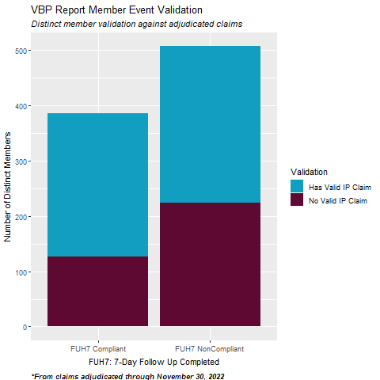

Alliance Provider performance scores were underated (red blocks) by at least 4 percentage points in 2022

Underrating performance frustrates the leadership and dampens the spirits of the clinical teams as they do this very difficult work.

Accurate measurement offers a better opportunity to identify patients in need, maximize financial incentives associated with performance, and support provider morale.

# Setting up the experiment

This manuscript is written using Brisk-DM. Brisk-DM is a structure for doing data science that is based on CRISP-DM[^5], but tailored for executives and business leads. Brisk-DM uses an approachable communication style that is more understandable to professionals in the workplace.

## The current state of things

At the time of this writing, The Alliance has received the first 3 months of VBP Quality Rosters the 2023 measurement year. Our application of the VBP Validation Model for FUH7 in June 2023 revealed a similar pattern to 2022 where we found that FUH was underrated[^6].

These results for FUH are under further investigation while we develop this model for AMM.

## Hablemos de dato (Let’s talk about the data)

This data model is simple in concept, but complex in design. The model compares *Report Data* from the HC VBP Quality Roster with *Real Data* from Health Choice adjudicated claims.

### What are the data sources?

VBP Quality Roster

Adjudicated Claims

- Health Choice receives this data from third party vendor, Cotivity
- An excel workbook containing a roster of the members deemed eligible for VBP HEDIS NCQA measures and their compliance status
- The Alliance receives individual rosters for each Alliance Provider
- A data set of adjudicated claims queried directly from the HCA data warehouse
- Records are gathered from the Claims and PBM databases
- Claims are extracted for all eligible service codes for the measurement year

### Is the data we use reliable?

VBP Quality Roster

Adjudicated Claims

- The outstanding question with the VBPQR is if the underlying data from the third party vendor Cotivity is accurate.
- The report quality itslef is very high as it is compiled by Health Choice Business Intelligence staff.
- The underlying data is what is under investigation
- Claims data is of the highest quality as it is compiled and reviewed extensively by Health Choice for its own business purposes.
- The quality of this data is also reviewed by state and federal regulation entities, like AHCCCS

## The AMM Eligibility Model

We now embark upon building a data set of eligible claims for the AMM measure. This process will be significantly more complicated than our previous model for FUH. The description of an eligible member event is very nuanced for AMM, but in short…

**An eligible member event is defined as follows:**

- The individual is an adult, aged 18 or older, **and**
- A prescription is filled for an eligible antidepressant medication within the “Intake Period” (*Index Prescription Start Date (IPSD)*), **and**
- No other prescriptions were filled for eligible antidepressant medications within 105 days earlier than the IPSD (*Test for Negative Medication History (NMH)*), **and**
- The individual had a service for one of the eligible Major Depressive Disorders (*Test for Major Depressive Disorder (MDDx)*) within 60 days (-60 days before, or +60 days after), **and**
- The individual had continuous enrollment (*Test for Continuous Enrollment (CE)*)for
  - 105 days before the IPSD, **and**
  - 231 days after the IPSD

Check out the visualization of the AMM Eligibility Model below. There are many components of this model with overlapping time frames. We will describe these steps in further detail in the next section.

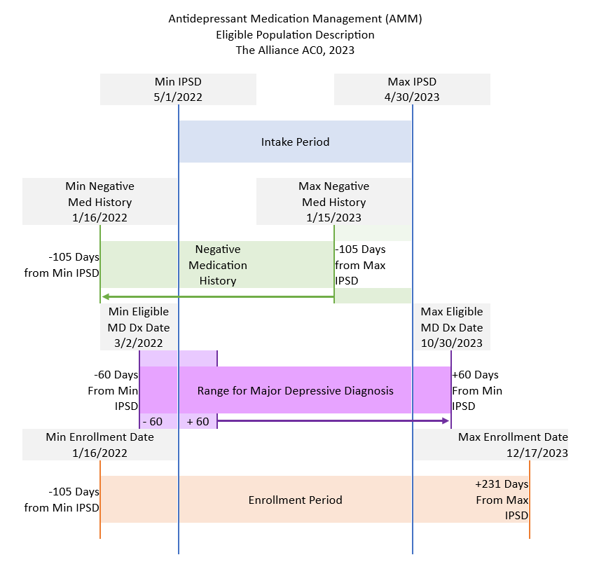

AMM Eligibility Model (Kivela, 2023)

Refer to the visualization above, or think of the criteria as a tumbling bike lock.

There are 4 primary criteria:

- Index Prescription Start Date (IPSD)
- Negative Medication History (NMH)
- Major Depressive Diagnosis (MDDx)
- Continuous Enrollment (CE)

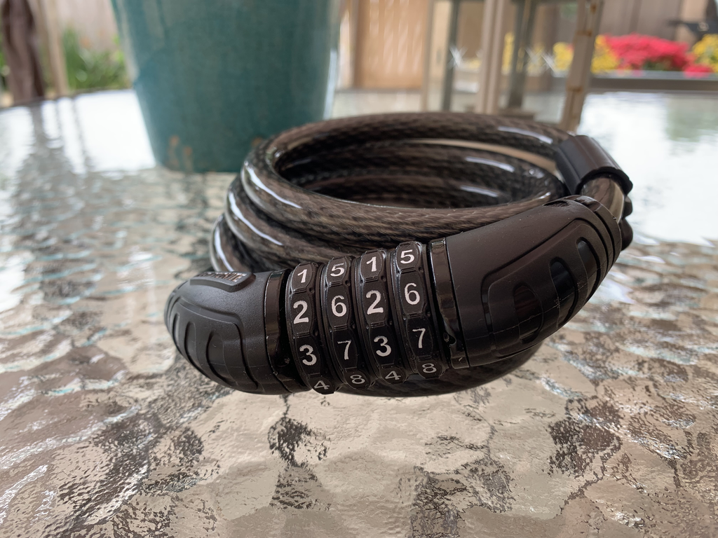

All four criteria must line up, *in the right order*, for the lock to open. Once unlocked, the resulting data set es El Dato Verdad, the **Real Data**.

### The Index Prescription Start Date

The first criteria that must be met is the Index Prescription Start Date (IPSD). This is the date that an individual filled a prescription for one of the HEDIS My 2023 eligible medications.

**Description**

The IPSD is the anchor point for the rest of the eligibility measures. An individual must have an eligible IPSD in order to be assessed against the other tests for this measure.

The member must have a prescription refill for an eligible Antidepressant Medication between the eligible dates indicated in the visualization above.

**Procedure**

In order to assess IPSD we did the following:

The 12 month Intake Period begins on May 1 of the *year prior* to the Measurement Year

- The Measurement Year is: *01-01-2023 to 12-31-2023*
- The Intake Period is: *05-01-2022 to 04-30-2023*
- We extract claims from the *PBM database* at the Health Choice data warehouse for the given My2023 eligible medications dispensed within the Intake Period.
- The NDC to GPI crosswalk must be used to determine eligible medications. The code to create the crosswalk is in the Appendix.
- The minimum date of the Test for Negative Medication History must also be included in the PBM Claims query. The test for NMH is outlined below.
- The Negative Medication History range is: *01-16-222 to 01-15-2023*
- The prescription fill date in this range is called the *Index Prescription Start Date (IPSD)*

**Code**

Here is the code to extract claims data from HC data warehouse

```sql
# Declare Date Range
Declare @start as date = '01-16-2022'
Declare @end as date = '04-30-2023'

SELECT
  pbm.clientID,
  id.PrimaryId,
  pbm.AsOfDate,
  pbm.dtefilled,
  pbm.GpiNumber,
  pbm.GPIClassification,
  pbm.prodname,
  pbm.genericnme,
  pbm.LabelName,
  pbm.GroupId,
  pbm.preslstnme,
  pbm.pbmrxclaimnbr,
  pbm.claimsts,
  pbm.AmtPaidFinal,
  pbm.productid,
  pbm.decimalqty,
  pbm.dayssupply,
  pbm.Gender,
  pbm.birthdte,
  pbm.mbrage

FROM
  PBM.dbo.HCICPharmacyClaimSummary pbm
  LEFT OUTER JOIN GlobalMembers.dbo.ClientIdPlus id ON pbm.clientID = id.AzAhcccsId

WHERE
  pbm.dtefilled BETWEEN @start AND @end
    AND
    pbm.mbrage >= 18
    AND
    pbm.GpiNumber IN (concatenated_values_GPI)
```

```r
# Import the raw claims
PBMClaims <- read.csv("./data/DataRaw_PBMClaims_2023-05-31.csv")

# Convert numeric variable to date
PBMClaims$dtefilled <- as.Date(as.character(PBMClaims$dtefilled), format = "%Y%m%d")

# Convert character variable to date
PBMClaims$AsOfDate <- as.Date(PBMClaims$AsOfDate, format = "%m/%d/%Y")

# write.csv(PBMClaims, "./data/output/PBMClaims.csv")

PBMClaims_NMHTest <- PBMClaims

# Convert the 'dtefilled' column to Date type if it's not already in the correct format
PBMClaims_NMHTest$dtefilled <- as.Date(PBMClaims_NMHTest$dtefilled)

# Define the start and end dates for IPSDTestResult
ip_start_date <- as.Date("2022-05-01")
ip_end_date <- as.Date("2023-04-30")

# Create the IPSDTestResult column based on the date conditions
# A result of "TRUE" indicates a positive IPSD
PBMClaims_NMHTest$IPSDTestResult <- ifelse(
  PBMClaims_NMHTest$dtefilled >= ip_start_date
  & PBMClaims_NMHTest$dtefilled <= ip_end_date, "TRUE", "FALSE")
```

### Test for Negative Medication History (NMH)

**Description**

**Be patient.** This part of the program takes about 20 minutes to run. If you think about what it is doing, it is comparing every row of claims (~147,000 rows) against the IPSD Intake Period range, and for all of the positive returns, comparing each one to each of the the original 147,000 rows for the NMH test.

Think about trying to guess the first 2 numbers on the bike lock, multiplied by 147,000. Anyway, it’s a lot. Go grab some coffee.

**Procedure**

**In order to conduct the test for Negative Medication History we took the following steps:**

*What in the world are we supposed to do with this!? Layers upon layers. Ok, here goes, take 2,*

The PBM Claims data set is queried from the Health Choice data warehouse using the procedure outlined above. This initial pull includes the entire potential range of PBM Claims for the Intake Period **and** the Negative Medication History period. Refer again to the visualization above for a visual aid.

Be patient. This part of the program takes about 20 minutes to run. If you think about what it is doing, it is comparing every row (147,000 rows) against the IPSD range, and for all the positive returns comparing each one to each of the the original 147,000 rows for the NMH test. Think about trying to guess the first 2 numbers on the bike lock. Anyway, it’s a lot. Go grab some coffee.

**Code**

This is the code my friends

```r
# Initialize NMHTestResult column with empty values
PBMClaims_NMHTest$NMHTestResult <- ""

# Loop through each row of the data frame
for (i in 1:nrow(PBMClaims_NMHTest)) {
  # Get the current ClientID, GpiNumber, and IPSDTest date
  current_client <- PBMClaims_NMHTest$clientID[i]
  current_gpi <- PBMClaims_NMHTest$GpiNumber[i]
  ipsd_test_date <- PBMClaims_NMHTest$dtefilled[i]

  # Find any matching observation with the same ClientID, GpiNumber, and a date less than 105 days before the IPSDTest date
  matching_observation <- PBMClaims_NMHTest$clientID[
    PBMClaims_NMHTest$clientID == current_client
    & PBMClaims_NMHTest$GpiNumber == current_gpi

## This is the problematic bit right here. Less than or greater than?
    & PBMClaims_NMHTest$dtefilled < ipsd_test_date - 105]

  # If there is no matching observation, update the NMHTestResult value for the current row
  if (length(matching_observation) != 0) {
    PBMClaims_NMHTest$NMHTestResult[i] <- "TRUE"
  } else {
    # If there is no matching observation, update the NMHTestResult value for the current row as "FALSE"
    PBMClaims_NMHTest$NMHTestResult[i] <- "FALSE"
  }
}
# write.csv(PBMClaims_NMHTest, "./data/output/PBMClaims_NMHTest_copy.csv")
```

**Fantastico!**

Wow! I can’t believe that we actually pulled that off!

Now we have our confirmation of IPSD and NMH.

Two down, two to go. Awesome!

Next up is to determine if there was an eligible diagnosis

### Test for Major Depressive Disorder

The next stop on the road is to confirm that the individual had a service for one of the eligible Major Depressive Disorders (MDDx) within 60 days, (-60 days before, or +60 days after).

**Description**

A diagnosis of Major Depressive Disorder is identified by cross referencing members with eligible IPSD and NMH, which is determined using PBM records, against claims records from the Claims database. Individual identifying data is used to join PBM records with claims records.

**Procedure**

So we have to use BHClaims.

It’s going to be pull for the dates (refer to visual) .

Then we have to get the claims from claims.dbo.shcavos. We use the techniqu as the FUH model. Same code excpet search for Dx instead of svccode.

Pull the list of MDDx diagnosis codes

**Code**

##### Import the HEDIS My2023 value set for eligible Major Depressive Diagnoses

```r
# Import the Value Set List
ValueSetListMy2023 <- read.csv("./data/ValueSetListMy2023.csv")

# Create a list of the diagnosis codes
MDDxList <- ValueSetListMy2023$Code

# Concatenate for adding to sql
concatenated_values_MDDx <- paste0("(",    ValueSetListMy2023$Code, ")", collapse = ", ")
```

##### Query the Health Choice data warehouse for eligible MDDx claims

```sql
-- Declare start and end variables
DECLARE @start DATE = '2022-03-22';
DECLARE @end DATE = '2023-10-30';

-- Check if the temporary table exists and drop it if it does
IF OBJECT_ID('tempdb..#ValueSetListMy2023') IS NOT NULL
    DROP TABLE #ValueSetListMy2023;

-- Create a temporary table
CREATE TABLE #ValueSetListMy2023 (Code VARCHAR(100) COLLATE SQL_Latin1_General_CP1_CI_AS);

-- Insert values into the temporary table
INSERT INTO #ValueSetListMy2023 (Code)
VALUES ('101'), ('100'), ('207'), ('116'), ('126'), ('136'), ('146'), ('156'), ('110'), ('120'),
       ('130'), ('140'), ('150'), ('160'), ('170'), ('190'), ('200'), ('210'), ('1000'),
       ('213'), ('214'), ('206'), ('202'), ('111'), ('121'), ('131'), ('141'), ('151'),
       ('211'), ('171'), ('172'), ('173'), ('174'), ('122'), ('132'), ('142'), ('152'),
       ('112'), ('117'), ('127'), ('137'), ('147'), ('157'), ('119'), ('129'), ('139'),
       ('149'), ('159'), ('169'), ('219'), ('209'), ('179'), ('199'), ('113'), ('123'),
       ('133'), ('143'), ('153'), ('203'), ('114'), ('124'), ('134'), ('144'), ('154'),
       ('204'), ('212'), ('118'), ('128'), ('138'), ('148'), ('158'), ('1002'), ('1001'),
       ('167'), ('164'), ('191'), ('192'), ('193'), ('194'), ('201'), ('208'), ('F32.0'),
       ('F32.1'), ('F32.2'), ('F32.3'), ('F32.4'), ('F32.9'), ('F33.0'), ('F33.1'), ('F33.2'),
       ('F33.3'), ('F33.41'), ('F33.9'), ('14183003'), ('2618002'), ('726772006'),
       ('320751009'), ('36923009'), ('370143000'), ('1.08111E+16'), ('1.08112E+16'),
       ('42925002'), ('69392006'), ('63778009'), ('25922000'), ('87512008'), ('79298009'),
       ('1.6266E+16'), ('40379007'), ('720455008'), ('720454007'), ('720451004'), ('832007'),
       ('15639000'), ('1.62668E+16'), ('18818009'), ('719592004'), ('720453001'),
       ('720452006'), ('66344007'), ('38694004'), ('39809009'), ('319768000'), ('71336009'),
       ('268621008'), ('191610000'), ('191611001'), ('191613003'), ('1.62646E+16'),
       ('1.62649E+16'), ('1.62648E+16'), ('450714000'), ('73867007'), ('33736005'),
       ('60099002'), ('75084000'), ('2.51E+11'), ('430852001'), ('77911002'), ('20250007'),
       ('76441001'), ('1.6267E+16'), ('2.81E+11'), ('28475009'), ('33078009'), ('15193003'),
       ('36474008'), ('191604000');

-- Query to retrieve data from the claims.dbo.shcavos table
SELECT DISTINCT
    shcavos.primaryID,
    id.BCBSMedicaidId AS MemberID,
    shcavos.begDate,
    shcavos.PrimaryDiagnosis,
    shcavos.Dx1,
    shcavos.Dx2,
    shcavos.Dx3,
    shcavos.Dx4,
    shcavos.Dx5,
    shcavos.Dx6,
    shcavos.Dx7,
    shcavos.Dx8,
    shcavos.Dx9,
    shcavos.Dx10,
    shcavos.Dx11,
    shcavos.Dx12,
    CASE WHEN v.Code IS NOT NULL THEN 'True' ELSE 'False' END AS MatchFound
FROM claims.dbo.shcavos AS shcavos
LEFT JOIN GlobalMembers.dbo.ClientIdPlus id ON shcavos.primaryID = id.primaryID
LEFT JOIN #ValueSetListMy2023 AS v ON shcavos.PrimaryDiagnosis COLLATE SQL_Latin1_General_CP1_CI_AS = v.Code
                                    OR shcavos.Dx1 COLLATE SQL_Latin1_General_CP1_CI_AS = v.Code
                                    OR shcavos.Dx2 COLLATE SQL_Latin1_General_CP1_CI_AS = v.Code
                                    OR shcavos.Dx3 COLLATE SQL_Latin1_General_CP1_CI_AS = v.Code
                                    OR shcavos.Dx4 COLLATE SQL_Latin1_General_CP1_CI_AS = v.Code
                                    OR shcavos.Dx5 COLLATE SQL_Latin1_General_CP1_CI_AS = v.Code
                                    OR shcavos.Dx6 COLLATE SQL_Latin1_General_CP1_CI_AS = v.Code
                                    OR shcavos.Dx7 COLLATE SQL_Latin1_General_CP1_CI_AS = v.Code
                                    OR shcavos.Dx8 COLLATE SQL_Latin1_General_CP1_CI_AS = v.Code
                                    OR shcavos.Dx9 COLLATE SQL_Latin1_General_CP1_CI_AS = v.Code
                                    OR shcavos.Dx10 COLLATE SQL_Latin1_General_CP1_CI_AS = v.Code
                                    OR shcavos.Dx11 COLLATE SQL_Latin1_General_CP1_CI_AS = v.Code
                                    OR shcavos.Dx12 COLLATE SQL_Latin1_General_CP1_CI_AS = v.Code
WHERE shcavos.begDate BETWEEN @start AND @end
AND CASE WHEN v.Code IS NOT NULL THEN 'True' ELSE 'False' END = 'True';

# Save the result as MDDxClaims_dateslug.csv
```

##### Load data from the claims query results into the data model

```r
# Import the MDDxClaims from excel
MDDxClaims <- read_csv("./data/MDDxClaims_20230602.csv")
```

##### Conduct the MDDx Test

```r
# Load the MDDxClaims data
MDDxClaimsTest <- MDDxClaims %>%
  rename(PrimaryId = primaryID)

# Merge PBMClaims_NMHTest and MDDxClaims on PrimaryId, keeping all rows and columns
PBMClaims_MDDxMerge <- merge(x = PBMClaims_NMHTest, y = MDDxClaimsTest, by = "PrimaryId", all = TRUE)

PBMClaims_MDDxTest <- PBMClaims_MDDxMerge

# Create a new column called MDDxTestResult and conduct test
PBMClaims_MDDxTest$MDDxTestResult <- ifelse(abs(as.numeric(as.Date(PBMClaims_MDDxTest$begDate) - as.Date(PBMClaims_MDDxTest$dtefilled))) <= 60, TRUE, FALSE)

# Select the columns of interest, change name to _MDDXTest
PBMClaims_MDDxTest <- PBMClaims_MDDxTest[, c("PrimaryId", "clientID", "MemberID", "dtefilled", "IPSDTestResult", "NMHTestResult" , "MDDxTestResult", "begDate", "PrimaryDiagnosis", "GpiNumber", "LabelName", "preslstnme", "decimalqty", "dayssupply", "AmtPaidFinal")]
```

**Woo hoo! It worked!**

We have now determined that there is:

1. A valid Index Prescription Start Date
2. A Negative Medication History
3. A valid service for Major Depressive Disorder

### Test for Continuous Enrollment

Ok, three down, one to go. Awesome!

Now that we have confirmed IPSD, NMH, and MDDx, we will compare the member information against our enrollment records to determine there was an eligible enrollment period associated with the prescription fill.

**Description**

An event is eligible if the individual had continuous enrollment for -105 days before the IPSD, **AND** +231 days after the IPSD.

**Procedure**

Ok, so what do we do here???

Take our main table, now called PBMClaims_MDDxTest. Compare the PrimaryId Associated with the event against our member enrollment roster developed in the Alliance Progress Report [^7]. This is the full global members roster because we are not filtering for active membership only. Individuals who are currently disenrolled are included as well.

First, confirm if the eligible event matches anyone on the enrollment roster.

**Code**

Here’s the code

```r
# Import the original global members roster
GlobalMembers_orig <- read_xlsx("./data/data_original_glblmbrs_2023-05-01_globalMembersRoster.xlsx", sheet = "Sheet1")

# Create a working copy and rename "x" to PrimaryId
GlobalMembers <- GlobalMembers_orig |>
  rename("PrimaryId" = x)

# Using the PBMClaims_MDDxTest table as a base, attach Global Members data by PrimaryId
PBMClaims_CETest1 <- merge(x = PBMClaims_MDDxTest,
              y = GlobalMembers,
              by = "PrimaryId",
              all.x = TRUE)

# Continuous Enrollment Test (Pre)

# Calculate the difference in days. If and only if bhhEffectiveDate is earlier than the dtefilled, then return the number of days between the bhhEffectiveDate and the dtefilled
PBMClaims_CETest1$CEDaysDiff_Pre <- ifelse(PBMClaims_CETest1$bhhEffectiveDate < PBMClaims_CETest1$dtefilled,
                                   as.integer(difftime(PBMClaims_CETest1$dtefilled, PBMClaims_CETest1$bhhEffectiveDate, units = "days")),
                                   NA)

# Create the DaysDiff_PreTest column
PBMClaims_CETest1$CEDaysDiff_PreTest <- PBMClaims_CETest1$CEDaysDiff_Pre > 105


# Continuous Enrollment Test (Post)

# Calculate the difference in days only if bhhEffectiveDate is before dtefilled
PBMClaims_CETest1$CEDaysDiff_Post <- ifelse(PBMClaims_CETest1$bhhEffectiveDate < PBMClaims_CETest1$dtefilled,
                                   as.integer(difftime(PBMClaims_CETest1$dtefilled, PBMClaims_CETest1$bhhEffectiveDate, units = "days")),
                                   NA)

# Get today's date
today <- Sys.Date()

# If disenrollment date is null (meaning still enrolled), then return the number of days between dtefilled and today. If the disenrollmentDate is not null (Meaning the person is disenrolled) then calculate the number of days between the dtefilled and the disenrollment date.
PBMClaims_CETest1$CEDaysDiff_Post <- ifelse(is.na(PBMClaims_CETest1$disenrollmentDate),
                                   as.integer(difftime(today, PBMClaims_CETest1$dtefilled, units = "days")),
                                   ifelse(PBMClaims_CETest$disenrollmentDate > PBMClaims_CETest1$dtefilled,
                                          as.integer(difftime(PBMClaims_CETest1$disenrollmentDate, PBMClaims_CETest1$dtefilled, units = "days")),
                                          NA))

# Create the DaysDiff_PostTest column
PBMClaims_CETest1$CEDaysDiff_PostTest <- PBMClaims_CETest1$CEDaysDiff_Post > 231

# Conduct test to see if both pre and post conditions are met
# Create new column "CETestResult"
PBMClaims_CETest1$CETestResult <- ifelse(PBMClaims_CETest1$CEDaysDiff_PostTest & PBMClaims_CETest1$CEDaysDiff_PreTest, TRUE, FALSE)

# Select Choice variables:
PBMClaims_CE_Test <- PBMClaims_CETest1[, c("PrimaryId", "clientID", "dtefilled", "IPSDTestResult", "NMHTestResult", "MDDxTestResult", "CETestResult", "begDate", "PrimaryDiagnosis", "GpiNumber", "LabelName", "preslstnme", "decimalqty", "dayssupply", "CEDaysDiff_Pre", "CEDaysDiff_Post", "AmtPaidFinal")]

# Sort the data
PBMClaims_CE_Test <- PBMClaims_CE_Test %>%
  arrange(desc(PrimaryId), desc(dtefilled), IPSDTestResult)
```

```r
# Conduct the AMM Eligibility Test

# Convert the variables to logical if needed
PBMClaims_CE_Test$IPSDTestResult <- as.logical(PBMClaims_CE_Test$IPSDTestResult)
PBMClaims_CE_Test$NMHTestResult <- as.logical(PBMClaims_CE_Test$NMHTestResult)
PBMClaims_CE_Test$MDDxTestResult <- as.logical(PBMClaims_CE_Test$MDDxTestResult)
PBMClaims_CE_Test$CETestResult <- as.logical(PBMClaims_CE_Test$CETestResult)

# Create the new column "AMMEligibilityTest"
PBMClaims_CE_Test$AMMEligibilityTestResult <- with(PBMClaims_CE_Test, IPSDTestResult & NMHTestResult & MDDxTestResult & CETestResult)

# Select Choice variables:
AMMEligibilityTest <- PBMClaims_CE_Test[, c("PrimaryId", "clientID", "dtefilled", "AMMEligibilityTestResult", "IPSDTestResult", "NMHTestResult", "MDDxTestResult", "CETestResult", "begDate", "PrimaryDiagnosis", "GpiNumber", "LabelName", "preslstnme", "decimalqty", "dayssupply", "CEDaysDiff_Pre", "CEDaysDiff_Post", "AmtPaidFinal")]

# Sort the data
AMMEligibilityTest <- AMMEligibilityTest %>%
  arrange(desc(PrimaryId), desc(dtefilled), AMMEligibilityTestResult)

# write.csv(AMMEligibilityTest, "./data/output/AMMEligibilityTest.csv")

# write.csv(AMMEligibilityTest, "./data/output/AMMEligibilityTest_Copy.csv")
```

**AMM Eligibility, Check!**

We have now determined that there is:

1. A valid Index Prescription Start Date
2. A Negative Medication History
3. A valid service for Major Depressive Disorder
4. A valid period of enrollment

## Value-based Purchasing Quality Reports (VBP QR)

**Description**

The VBP Roster comes to us from Health Choice, but the underlying data is analyzed and produced by a third party vendor, Cotivity.

The Alliance receives a separate report for each of the Alliance Providers. This procedure outlines how the VBP QR is input from the original report and transformed to actionable data.

The resulting table is a complete, cleaned roster of all of the individual member events, for all of the VBP Measures, for all of the Alliance Providers. It is then filtered to assess each measure individually.

*This table is used to construct the VBP Quality Report Dashboard as well as the Alliance Progress Report*

**Procedure**

The Table, *DataRaw_VBPQR_AllAPsCombined,* is then transformed in order to remove superfluous white space and other text and table titles that were imported by default.

A copy of the file *VBPQR_AllAPsCombined_Cleaned,* was stored as *VBPQR_AllAPsCombined_Cleaned2* for use later.

**Code**

```r
# Import the unaltered VBP report, "Detail" sheet, as received from HCA
# 5/1/23 sheet = "Detail" was change by HCA to sheet = "Roster"
vbp_cbi   <-  read_xlsx("./data/VBPReports/Quality/vbpbhh_report_2023-05-31_94-2880847_Community_Bridges_HCA_BHH_VBP_Quality_Roster.xlsx", sheet = "Roster")
##  vbp_cbi <- vbp_cbi [,-1]
##  colnames(vbp_cbi) <- c("BCBSAZ Health Choice" ,"...2", "...3", "...4", "...5", "...6", "...7", "...8", "...9")
vbp_cpih  <-  read_xlsx("./data/VBPReports/Quality/vbpbhh_report_2023-05-31_86-0215065_Change_Point_Integrated_Health_HCA_BHH_VBP_Quality_Roster.xlsx", sheet = "Roster")
vbp_lcbhc <-  read_xlsx("./data/VBPReports/Quality/vbpbhh_report_2023-05-31_86-0250938_Little_Colorado_Behavioral_Health_HCA_BHH_VBP_Quality_Roster.xlsx", sheet = "Roster")
vbp_mmhc  <-  read_xlsx("./data/VBPReports/Quality/vbpbhh_report_2023-05-31_86-0214457_Mohave_Mental_Health_HCA_BHH_VBP_Quality_Roster.xlsx", sheet = "Roster")
vbp_ph    <-  read_xlsx("./data/VBPReports/Quality/vbpbhh_report_2023-05-31_86-0206928_Polara_Health_HCA_BHH_VBP_Quality_Roster.xlsx", sheet = "Roster")
vbp_sbhs  <-  read_xlsx("./data/VBPReports/Quality/vbpbhh_report_2023-05-31_86-0290033_Southwest_Behavioral_Health_HCA_BHH_VBP_Quality_Roster.xlsx", sheet = "Roster")
vbp_shg   <-  read_xlsx("./data/VBPReports/Quality/vbpbhh_report_2023-05-31_86-0207499_Spectrum_Health_Group_HCA_BHH_VBP_Quality_Roster.xlsx", sheet = "Roster")
vbp_tgc   <-  read_xlsx("./data/VBPReports/Quality/vbpbhh_report_2023-05-31_86-0223720_The_Guidance_Center_HCA_BHH_VBP_Quality_Roster.xlsx", sheet = "Roster")

# Pro Tip
# if any of the tables pick up rogue columns...
# vbp_cbi <- vbp_cbi [,-1]
# colnames(vbp_cbi) <- c("BCBSAZ Health Choice" ,"...2", "...3", "...4", "...5", "...6", "...7", "...8", "...9")

# Bind the Details sheet from all providers into one table
DataRaw_VBPQR_AllAPsCombined <- rbind(
  vbp_cbi,
  vbp_cpih,
  vbp_lcbhc,
  vbp_mmhc,
  vbp_ph,
  vbp_sbhs,
  vbp_shg,
  vbp_tgc
)

# # write to csv
# date of file = date of VBP QR report
# write.csv(DataRaw_VBPQR_AllAPsCombined, "./data/output/VBPMeasurementValidation/2023-05-31_DataRaw_VBPQR_AllAPsCombined.csv")
```

```r
# create a safe copy of the original data
VBPQR_AllAPsCombined_Cleaned <- DataRaw_VBPQR_AllAPsCombined

# Filter out superfluous rows of nonsense data
VBPQR_AllAPsCombined_Cleaned <- VBPQR_AllAPsCombined_Cleaned |>
  filter(`...2` != "NA")

# Set column names to headers, which get imported on row 1 #5/2/23 - updated from "6"
colnames(VBPQR_AllAPsCombined_Cleaned) <- VBPQR_AllAPsCombined_Cleaned [1,]

# Remove the first row of data that headers
VBPQR_AllAPsCombined_Cleaned <- VBPQR_AllAPsCombined_Cleaned[-1,]

# 5/1/23 - Create SubMeasureID
VBPQR_AllAPsCombined_Cleaned$`SubMeasure ID` <- substr(VBPQR_AllAPsCombined_Cleaned$Measure, 1, 3)
```

```r
# create a duplicate at this phase to be used in later evaluation
VBPQR_AllAPsCombined_Cleaned2 <- VBPQR_AllAPsCombined_Cleaned |>
  filter(`SubMeasure ID` == "AMM")

# write.csv(VBPQR_AllAPsCombined_Cleaned2, "./data/output/VBPMeasurementValidation/VBPQR_AllAPsCombined_Cleaned2.csv")

# Isolate member ID for the validation
VBPQR_AllAPsCombined_Cleaned <- VBPQR_AllAPsCombined_Cleaned |>
  filter(`SubMeasure ID` == "AMM") |>
  select(`Member ID`)

# write.csv(VBPQR_AllAPsCombined_Cleaned, "./data/output/VBPMeasurementValidation/VBP_Validation.csv")
```

# AMM Validation Data Modeling

The terms for the Validation Model for AMM are *Conceptual* and *Logical*. This model will help to define the systems surrounding measurement of AMM. This model also outlines a set of logical rules and structures of data to be used across agencies.

This model extracts data from multiple VBP Quality Reports and aggregates it them into a single data set. It also collects adjudicated claims data from the Health Choice data warehouse.

The validation of VBP cases against adjudicated claims will tell us if the reports received through Health Choice’s 3rd party vendor are reliable and valid.

**Test Design**

[figure not shown]

**Procedure**

### Report Data: VBP Quality Roster Reports

*The VBPQR_AllAPsCombined_Cleaned* data frame was loaded to the test model. The data was summarized, per member, by counting the instances of eligibility per member. This creates a vector of unduplicated Member IDs called *VBP_Unduplicated*.

### Real Data: Adjudicated Claims

**Code**

```r
VBP_Unduplicated <- VBPQR_AllAPsCombined_Cleaned |>
  group_by(`Member ID`) |>
  rename("MemberID" = `Member ID`) |>
  count()

# write.csv(VBP_Unduplicated, "./data/output/VBPMeasurementValidation/VBP_Unduplicated.csv")
```

```r
AMMClaims_Unduplicated <- AMMEligibilityTest |>
  filter(MemberID != "NULL") |>
  group_by(MemberID) |>
  count()

# write.csv(IPClaims_Unduplicated, "./data/output/VBPMeasurementValidation/IPClaims_Unduplicated.csv")
```

# Appendix

### Create a GPI to NDC crosswalk

Because HCA categorizes their PBM claims in terms of Generic Product Identifier (GPI), but NCQA does theirs in terms of National Drug Code (NDC), we have to crosswalk the eligible AMM medications from NDC to their corresponding GPI codes. Fortunately, it’s totally not a pain in the neck to backwards engineer this at all, lol.

**Description**

The HEDIS My2023 Medication List Names identifies the eligible medications by providing the respective NDC numbers[^8]. The AHCCCS Preferred Drug List is used to match NDC numbers to GPI numbers based on medication name[^9].

**Procedure**

In order to create a cross walk that ties the NDC codes from NCQA to the GPI codes from Health Choice, we took the following steps:

- Import the My2023 Medication to Code data from the My2023 Medication List Directory[^10]
- Filter the data to only include Antidepressant Medications
- Rename some columns to provide consistency across tables
- Import the AHCCCS Preferred Drug List [^11]. A side by side list of NDC and GPI codes is incredibly difficult to come by, and so we are using this list from 2019. Fortunately NDC and GPI are very stable.
- Rename some columns to provide consistency across tables.
- Filter Therapeutic Class for Antidepressant Other, Antidepressant SSRI
- Merge the NCQA data set with the AHCCCS data set by matching on the the NDC variable.

**Code**

```r
# Covert NDC to GPI

#import the My2023 Medications to Code data set
Med_To_NDC <- read.csv("./data/My2023MedicationToCode.csv")

Med_To_NDC_AMM <- Med_To_NDC |>
  filter(Medication.List.Name == "Antidepressant Medications") |>
  select(
    Medication.List.Name,
    Code,
    Generic.Product.Name
  )

colnames(Med_To_NDC_AMM)[colnames(Med_To_NDC_AMM) == "Code"] <- "NDC_NationalDrugCode"

colnames(Med_To_NDC_AMM)[colnames(Med_To_NDC_AMM) == "Medication.List.Name"] <- "MedicationList"

colnames(Med_To_NDC_AMM)[colnames(Med_To_NDC_AMM) == "Generic.Product.Name"] <- "GenericProductName"

# Import AHCCCS Preferred drug list
NDC_To_GPI <- read.csv("./data/AHCCCS_PreferredDrugListChangesFor_08012019.csv")

colnames(NDC_To_GPI)[colnames(NDC_To_GPI) == "Therapeutic.Class...Market.Basket"] <- "TherepeuticClass"

colnames(NDC_To_GPI)[colnames(NDC_To_GPI) == "National.Drug.Code..NDC..MediSpan"] <- "NDC_NationalDrugCode"

colnames(NDC_To_GPI)[colnames(NDC_To_GPI) == "MediSpan.Generic.Product.Indicator..GPI."] <- "GPI_GenericProductIdentifier"


NDC_To_GPI_AMM <- NDC_To_GPI |>
  filter(c(TherepeuticClass == "ANTIDEPRESSANTS, OTHER" | TherepeuticClass ==  "ANTIDEPRESSANTS, SSRIs")) |>
  select(NDC_NationalDrugCode,
         GPI_GenericProductIdentifier,
         TherepeuticClass)

# merge then filter for only AHCCCS preferred medications

# So these are all of the ones from NCQA that AHCCCS has on thier list. And now we have our crosswalk to address claims.

My2023NDCtoGPICrosswalk <- merge(
  x = Med_To_NDC_AMM,
  y = NDC_To_GPI_AMM,
  by = "NDC_NationalDrugCode",
  all.y = TRUE
) |>
  select(
    MedicationList,
    TherepeuticClass,
    NDC_NationalDrugCode,
    GPI_GenericProductIdentifier,
    GenericProductName
  ) |>
  na.omit()

# write.csv(My2023NDCtoGPICrosswalk, "./data/output/My2023NDCtoGPICrosswalk.csv")

concatenated_values_GPI <- paste0("'",    My2023NDCtoGPICrosswalk$GPI_GenericProductIdentifier, "'", collapse = ", ")
```

## Footnotes

[^1]: Health Choice Arizona. (2023). *Value Based Purchasing Quality Roster*
[^2]: Kivela, J.R. (2023). Value Based Purchasing Data Validation Model. *The Northern Arizona Regional Behavioral Health Alliance*.
[^3]: https://www.ncqa.org/hedis/
[^4]: https://www.ncqa.org/hedis/
[^5]: CRISP-DM help overview. (August 17, 2021). https://www.ibm.com/docs/en/spss-modeler/saas?topic=dm-crisp-help-overview.
[^6]: Kivela, J.R. (June 13, 2023). Value Based Purchasing Data Validation Model. *The Northern Arizona Regional Behavioral Health Alliance*. (“./documents/report_updated_2023-03-29_VBPMeasurementValidation.html”)
[^7]: Alliance progress report (Kivela 2023)
[^8]: HEDIS Criteria reference
[^9]: HEDIS Criteria reference
[^10]: HEDIS Criteria reference
[^11]: HEDIS Criteria reference